# TP2 : Arbres

Author

Ema Cerezo

Published

September 27, 2023

## Classification avec les arbres

### Question 1

Dans le cadre de la régression, on cherche à prédire une valeur numérique pour Y, c’est-à-dire une valeur continue. Cela diffère de la prédiction d’une classe, qui correspond à une valeur discrète (ex: couleur des yeux, diagnostic médical…).

### Question 2

On souhaite comparer les pourcentages d’erreurs commises selon la profondeur maximale d’un arbre pour les mesures d’impureté suivantes :

- Indice de Gini
- Entropie

Pour ce faire, on procède de la manière suivante :

1. Simulation de deux échantillons de données de taille n = 456, grâce à la méthode `rand_checkers`, pour obtenir un ensemble de points aléatoires.
2. Pour chaque mesure d’impureté, construction de 12 arbres de décision et classification des données avec le package `tree` de `scikit-learn` (en faisant varier le paramètre `max_depth` de `tree.DecisionTreeClassifier` entre 1 et 12).
3. Attribution d’un score à chaque résultat obtenu.
4. Construction de deux courbes à analyser : Une pour l’indice de Gini et une pour l’entropie.

**1. Génération des échantillons**

```python
# Génération des échantillons
n = 114  # 456 = 114 * 4
data_raw = rand_checkers(n, n, n, n)
X_train = data_raw[:, :2]
Y_train = data_raw[:, 2].astype(int)
```

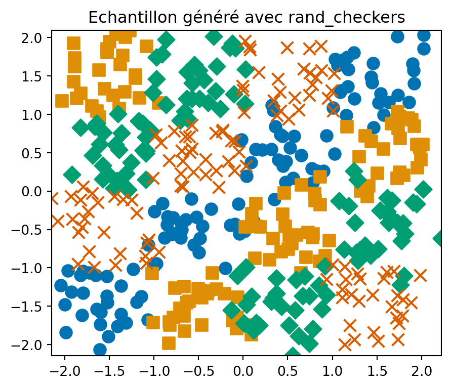

**2. 3. Instanciation des classifiers, entraînement et calcul des scores**

```python
# Instanciation et entraînement des classifiers
max_depth = 12
scores_entropy = np.zeros(max_depth)
scores_gini = np.zeros(max_depth)

clf_entropy = []  # (<- pour des raisons d'affichage, et parce qu'on va les)
clf_gini = []     # (réutiliser question 5.)
for i in range(max_depth):
    clf_entropy.append(DecisionTreeClassifier(criterion="entropy",
                                              max_depth=i + 1))
    clf_entropy[i].fit(X_train, Y_train)
    scores_entropy[i] = clf_entropy[i].score(X_train, Y_train)  # Calcul du score

    clf_gini.append(DecisionTreeClassifier(criterion="gini", max_depth=i + 1))
    clf_gini[i].fit(X_train, Y_train)
    scores_gini[i] = clf_gini[i].score(X_train, Y_train)
```

Voici les classes obtenues pour les valeurs 1 à 12 du paramètre `max_depth` pour `DecisionTreeClassifier(criterion="entropy")` :

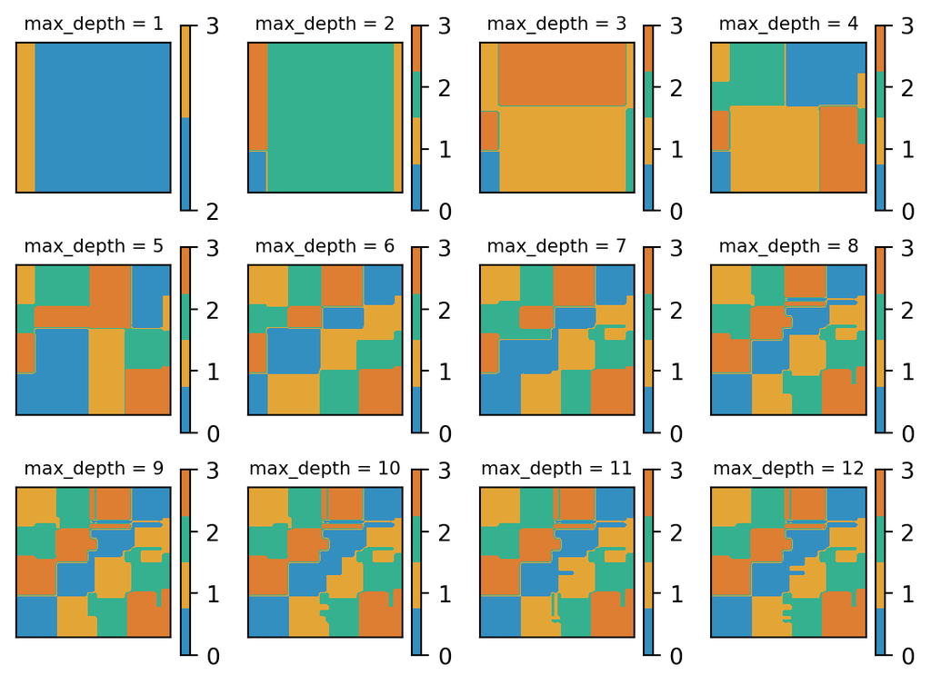

On constate qu’une profondeur d’arbre trop petite ne permet pas de distinguer des classes pertinentes dans l’échantillon *(max_depth = 1 à 5)*, tandis qu’une profondeur d’arbre trop grande semble capturer du bruit en plus de l’information de l’échantillon *(max_depth = 8 à 12)* (surapprentissage).

**4. Courbes de score**

Le score donne la proportion de prédictions correctement réalisées par le classifier. Ainsi, plus le score est petit, plus le pourcentage d’erreur est grand.

Les scores calculés précédemment donnent les courbes suivantes :

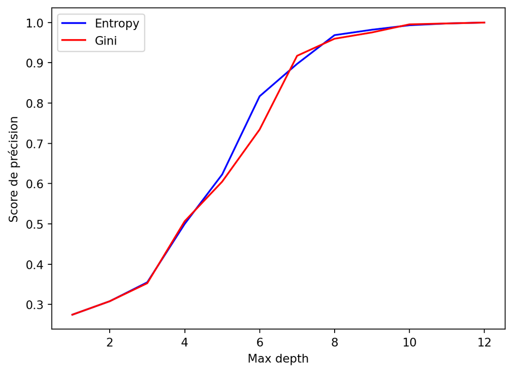

```
Score entropy pour max_depth = 5 : 0.6227678571428571
Score entropy pour max_depth = 7 : 0.8973214285714286
Score entropy pour max_depth = 8 : 0.96875
Score entropy pour max_depth = 10 : 0.9933035714285714
Score entropy pour max_depth = 12 : 1.0
```

Comme constaté précédemment, on remarque que pour une profondeur d’arbre inférieure ou égale à 5, la prédiction est peu fiable (environ une chance sur deux ou moins). Au-dessus de 8, la prédiction est précise à 95%. On remarque aussi que pour `max_depth = 12`, la prédiction est fiable à 100%, ce qui signifie que tout le bruit a été capturé par le modèle. Cela confirme donc notre hypothèse de surapprentissage pour une valeur trop élevée de profondeur d’arbre.

Les mesures d’impureté d’entropie et de Gini donnent des résultats similaires.

### Question 3

La profondeur qui minimise le pourcentage d’erreurs est celle qui a obtenu le score maximal :

```python
score_max, indice_max = scores_entropy[0], 0
for i, score in enumerate(scores_entropy):
    if score > score_max:
        score_max = score
        indice_max = i

print(f'Score entropy pour max_depth = {indice_max + 1} : {score_max}')
```

```
Score entropy pour max_depth = 12 : 1.0
```

Soit donc `max_depth = 12` (on le remarque également question précédente).

La classification associée est la suivante :

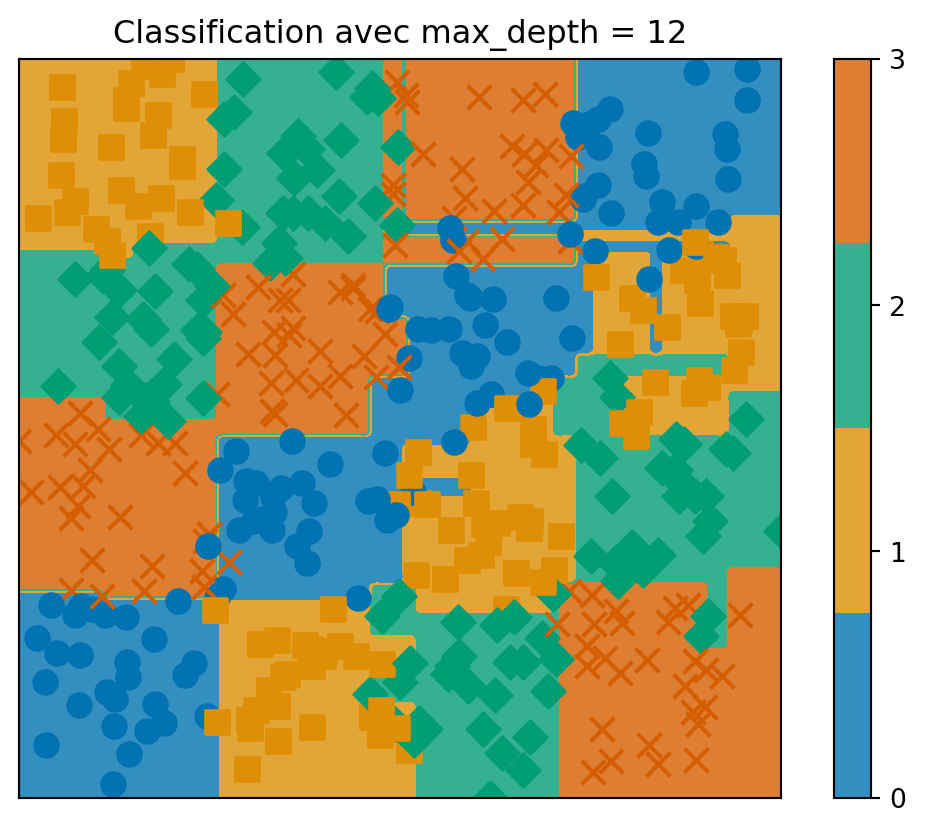

### Question 4

On exporte l’arbre maximal au format pdf.

```python
entropy_tree_graphviz = export_graphviz(clf_entropy[11], out_file=None,
                                             filled=True, rounded=True,
                                             special_characters=True)
graph = graphviz.Source(entropy_tree_graphviz)
output_file = graph.render(os.path.join("..", "dist", "entropy_max_tree"))
```

On obtient la représentation graphique de l’arbre avec ses règles de décision.

### Question 5

On génère un nouvel échantillon de taille $n = 160 = 40 + 40 + 40 + 40$ avec la méthode `rand_checkers`, et on tente d’en classifier les données avec les arbres entraînés précédemment pour des profondeurs d’arbres maximales allant de 1 à 12 (par entropie et par indice de gini). On calcule ensuite les scores obtenus pour les 2 * 12 classifications, et on trace deux courbes pour comparer ces résultats à ceux obtenus auparavant.

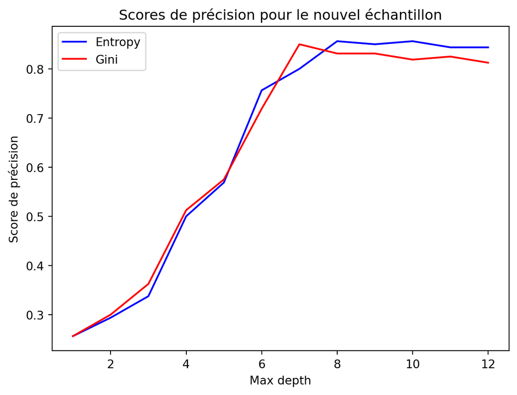

On remarque également que contrairement à la classification réalisée sur l’échantillon d’entraînement, celle réalisée sur l’échantillon de test n’arrive jamais à un score de 100% de précision quelle que soit la profondeur d’arbre maximale (ce qui semble cohérent puisque le score est calculé à partir d’une prédiction réalisée automatiquement sur les données d’entrée).

Voici les classes obtenues pour le critère d’entropie :

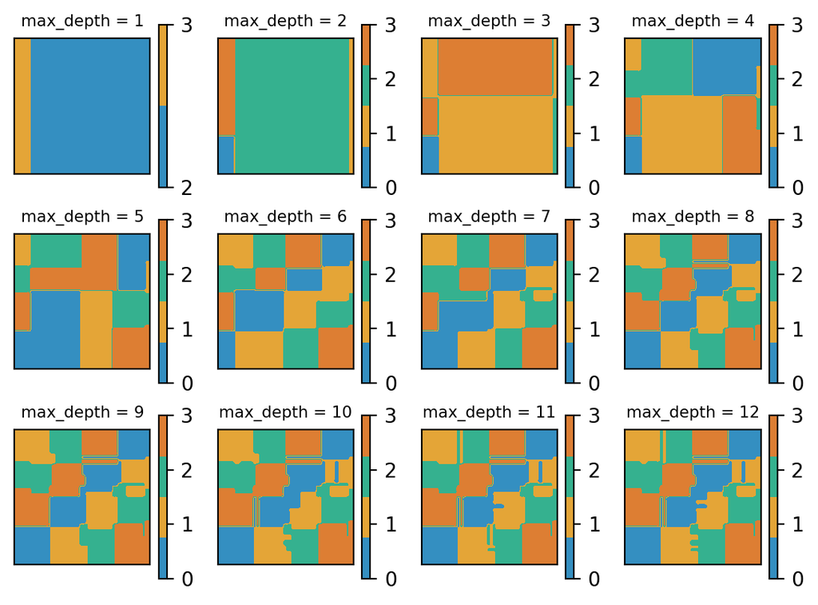

En particulier, voici celles obtenues pour `max_depth = 6` :

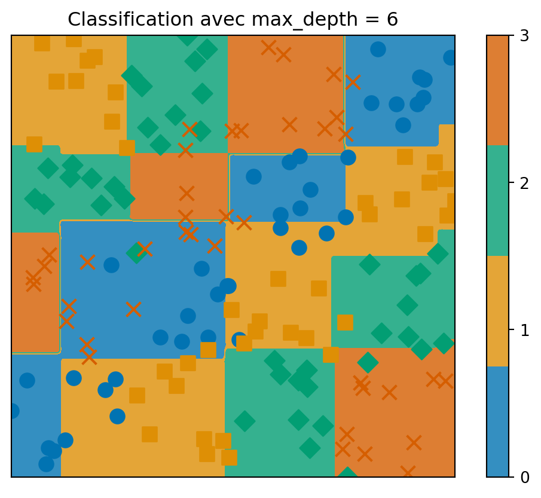

La prédiction semble plutôt juste.

### Question 6

Il s’agit maintenant de reprendre les questions précédentes pour un jeu de données réelles et non plus simulées. On commence par charger le jeu de données.

Il s’agit d’images de 8x8 pixels représentant des chiffres en noir et blanc, stockés sous forme de matrices :

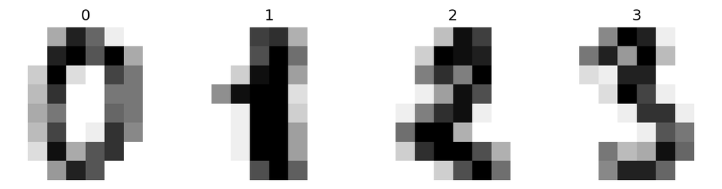

On entraîne des classifiers sur une partie des données du dataset (80% des données) et on teste les classifiers sur les 20% restants. On trace ensuite les courbes de score pour les données d’entraînement, et pour les données de test.

```python
n_samples = len(digits.images)
data = digits.images.reshape((n_samples, -1))
X_train, X_test, Y_train, Y_test = train_test_split(
    data, digits.target, test_size=0.2, shuffle=False
)

scores_entropy_train = np.zeros(max_depth)
scores_gini_train = np.zeros(max_depth)
scores_entropy_test = np.zeros(max_depth)
scores_gini_test = np.zeros(max_depth)

for i in range(max_depth):
    clf_entropy = DecisionTreeClassifier(criterion="entropy", max_depth=i + 1)
    clf_gini = DecisionTreeClassifier(criterion="gini", max_depth=i + 1)

    clf_entropy.fit(X_train, Y_train)
    clf_gini.fit(X_train, Y_train)

    scores_entropy_train[i] = clf_entropy.score(X_train, Y_train)
    scores_gini_train[i] = clf_gini.score(X_train, Y_train)
    scores_entropy_test[i] = clf_entropy.score(X_test, Y_test)
    scores_gini_test[i] = clf_gini.score(X_test, Y_test)
```

Les courbes obtenues sont les suivantes :

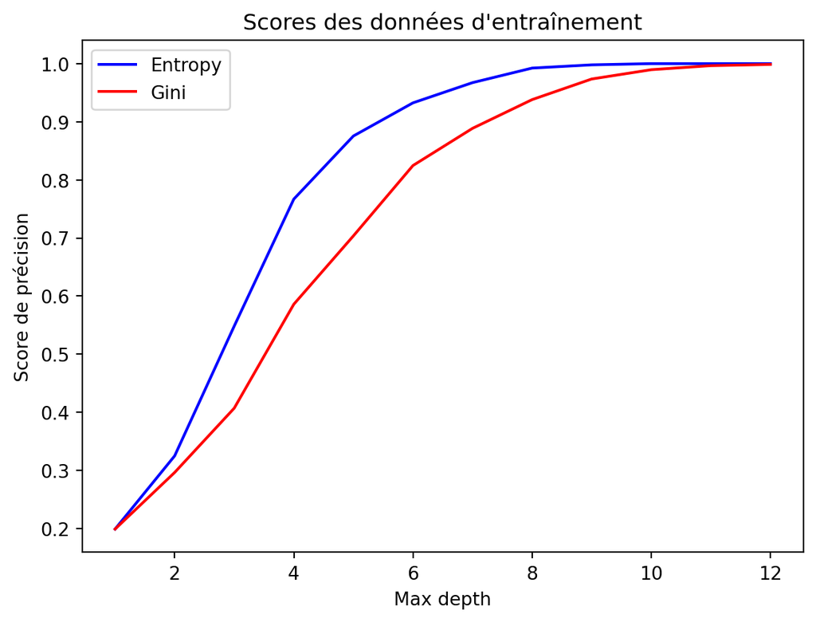

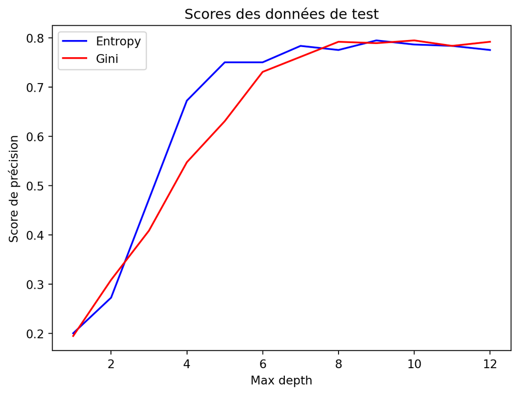

Cette fois encore, on constate que la classification ne dépasse pas les 80% de précision pour les données de test. Les courbes suggèrent également qu’une valeur de profondeur d’arbre de 6 ou 7 suffit pour classer efficacement les données.

## Méthodes de choix de paramètres - Sélection de modèle

### Question 7

On estime la profondeur d’arbre optimale par validation croisée : On choisit N = 5 pour la partition de l’ensemble d’apprentissage, puis on détermine la profondeur d’arbre pour laquelle le score de validation croisée est le meilleur grâce à la fonction `cross_val_score` de `sklearn. model_selection`.

```python
N = 5
max_score = 0

for depth in range(1, max_depth + 1):
    clf_entropy = DecisionTreeClassifier(criterion="entropy", max_depth=depth)
    score = np.mean(cross_val_score(clf_entropy, X_train, Y_train, cv=N))
    if score > max_score:
        optimal_depth = depth
        max_score = score

print(f'Profondeur optimale : {optimal_depth}')
```

```
Profondeur optimale : 10
```

### Question 8

Affichons les courbes d’apprentissage pour des profondeurs d’arbres allant de 1 à 12.

On commence par charger les données et créer le plot. Ensuite, pour chaque valeur de max_depth et sur l’axe adapté, on utilise la fonction `LearningCurveDisplay` de `sklearn.model_selection` pour afficher la courbe d’apprentissage de l’arbre correspondant. Celle-ci nous informe sur la qualité du modèle obtenu selon la taille de l’échantillon d’entraînement.

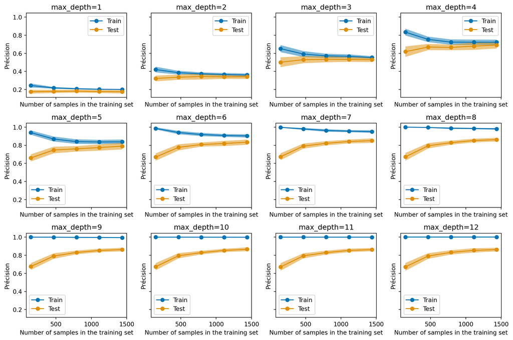

```python
X, y = load_digits(return_X_y=True)
fig, axes = plt.subplots(nrows=3, ncols=4, figsize=(12, 8), sharex=True,
                         sharey=True)

for depth, ax in zip(range(1, max_depth + 1), axes.ravel()):
    clf_entropy = DecisionTreeClassifier(criterion="entropy", max_depth=depth)
    train_sizes, train_scores, test_scores = learning_curve(clf_entropy, X, y, train_sizes=np.linspace(0.1, 1.0, 5), cv=N)

    common_params = {
        "X": X,
        "y": y,
        "train_sizes": np.linspace(0.1, 1.0, 5),
        "cv": ShuffleSplit(n_splits=50, test_size=0.2, random_state=0),
        "score_type": "both",
        "n_jobs": 4,
        "line_kw": {"marker": "o"},
        "std_display_style": "fill_between",
        "score_name": "Précision",
        "ax": ax
    }

    LearningCurveDisplay.from_estimator(clf_entropy, **common_params)
    ax.set_title(f"max_depth={depth}")
    ax.legend(loc='best')

plt.tight_layout()
plt.show()
```

On constate ici que plus les données de l’échantillon d’entraînement sont nombreuses, plus la classification est efficace. Cependant, la précision n’augmente pas énormément au-delà de 750 éléments, on en déduit donc qu’il serait possible de limiter l’entraînement à 50% du jeu de données sans que cela n’ait trop d’impact sur la précision du classifier. Néanmoins, une taille d’échantillon d’entraînement légèrement plus importante est toujours bonne à prendre (si possible), tant que cela ne rend pas les calculs trop longs.

On remarque également encore une fois que les données ne sont pas bien classées par des arbres dont la profondeur est inférieure à 6, et qu’il est peu pertinent de choisir une profondeur d’arbre supérieure à 8 (les graphiques sont les mêmes).